# CoMMpass

Genomics of 1,143 multiple myeloma patients over 8 years

John Gavin

## The patients

- CoMMpass enrolled **1,143 newly diagnosed myeloma patients** (2011–2019)
- Median age at diagnosis: **69 years** (range: 27–93)
- 8-year follow-up with RNA-seq, clinical records, and treatment data
- This is an **observational study**, not a drug trial — patients received whatever treatment their doctors chose

[output not shown]

## What 60,660 genes means

- The human genome has ~20,000 protein-coding genes
- The other ~40,000 are non-coding RNA (regulatory genes, pseudogenes)
- Every patient had the **same 60,660 genes measured** — what differs is how active each gene is
- Genes are spread across 23 chromosome pairs:
  - Chromosome 1 has ~2,000 genes; chromosome 21 has ~200
  - Myeloma-relevant: chromosome 14 (immunoglobulin genes), chromosome 17 (TP53 tumour suppressor)
- Known myeloma pathway genes: ~200–500 (from MSigDB)
- Each patient was sampled **once** (at diagnosis, before treatment)
  - Some patients had a second sample at relapse (~100 paired samples)
  - This study does not track gene changes continuously over time

## The data we have (part 1)

- **RNA-seq expression data** — 100 patient samples, 60,660 genes each
  - Measured once at diagnosis (some patients also at relapse)
  - Source: GDC STAR counts (60.5 MB)
- **Clinical metadata** — 995 patients, 88 variables each
  - Demographics (age, sex, race), staging (ISS), outcomes (alive/dead, days to death)
  - Source: GDC clinical endpoint (1.2 MB)

## The data we have (part 2)

- **Treatment records** — 7,184 drug administration records for 994 patients
  - Which drug, which line of therapy (1st, 2nd, 3rd…), start and end dates
  - Most patients received combination therapy (e.g. VRd = Bortezomib + Lenalidomide + Dexamethasone)
  - Patients who relapsed switched to later lines of therapy and stayed in the study
  - Source: extracted from GDC API (34 KB)
- **MSigDB gene sets** — 708 predefined gene groups (bundled in the R package)

## The data we don’t have

| Missing data | Why it matters | Why it’s missing |
| --- | --- | --- |
| FISH markers | Classify patients as high-risk vs standard-risk | Not in GDC open data; stored in MMRF Gateway |
| PFS endpoints | Measure how long treatment works | Not in GDC; requires MMRF Gateway |
| Treatment response | Did the drug work? (complete response, partial, stable, progression) | GDC field exists but is empty for all patients |
| Biomarker lab values | Track disease progression via blood tests | Stored in nested GDC data structures |

- Nested GDC fields: the biomarker values exist but are inside `molecular_tests` sub-records, not flat columns
  - Each patient has multiple test records at different dates
  - Parsing requires matching tests by date and type — not a simple column extraction
- 15 of 250 pipeline targets return empty because of these gaps
- Registration submitted to MMRF Researcher Gateway

## Who survives longer? Staging matters

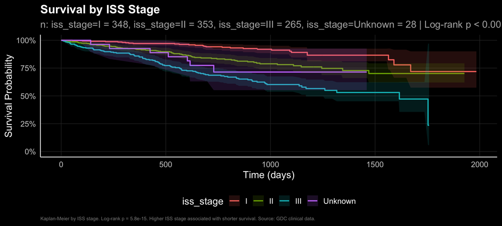

- ISS Stage III patients die at **5× the rate** of Stage I (HR = 4.9, p < 0.001)
- 994 patients total: 803 alive, 191 dead at last follow-up
- The three curves separate early and stay separated — staging predicts long-term outcome

## What predicts survival?

- A Cox regression adjusting for age, sex, and ISS stage:

| Factor | HR | What it means |
| --- | --- | --- |
| ISS II vs I | 2.4 | 2.4× higher death rate than Stage I |
| ISS III vs I | 4.9 | Nearly 5× higher death rate |
| Male vs female | 1.5 | 50% higher death rate for men |
| Age (per year) | Not significant | After adjusting for staging, age adds little |

- C-index = 0.687 — moderate discrimination (better than random, not perfect)

## Which genes differ between alive and dead patients?

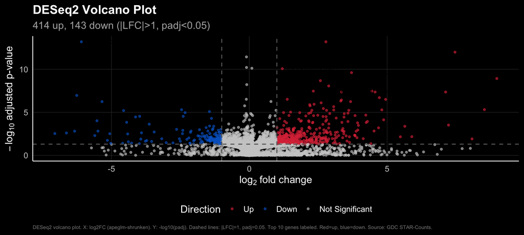

## Can we prove causation?

[figure not shown]

- This DAG maps our causal assumptions
- Chromosome changes → survival: **cannot be proven** because unmeasured tumour biology affects both
- ISS → survival: **can be estimated** if we adjust for age, chromosome changes, and gene expression

## Missing data tells a story

| Variable | What “missing” means | HR | p-value | What it means |
| --- | --- | --- | --- | --- |
| Cause of death | Patient is alive | ≈ 0 | 2 × 10⁻²⁶ | Missing = alive |

- Patients without a cause of death recorded are alive — the gap in the data **is** the answer
- The p-value of 2 × 10⁻²⁶ means:
  - The probability of seeing this association by chance is 0.00000000000000000000000002
  - With 994 patients (803 alive, 191 dead), the association between “missing cause of death” and “being alive” is essentially perfect
  - This is expected — it would be remarkable if it were NOT significant
- This is MNAR: the missingness is informative, not noise

## Summary

[output not shown]

- **Website**: [johngavin.github.io/coMMpass-analysis](https://johngavin.github.io/coMMpass-analysis/)
- **Code**: github.com/JohnGavin/coMMpass-analysis
- **Data**: [GDC portal](https://portal.gdc.cancer.gov/projects/MMRF-COMMPASS) (open access)
- **Study**: NCT01454297